# Analyses for slopes manuscript “Diversity and composition of riparian and upslope plant communities of small woodland streams”

Load required libraries

```r
require(lme4) #for GLMs
require(MDM) #for modeling an analogue to Shannon diversity (I will likely not end up using this)
```

```r
require(vegan) #for species accumulation curves and ordination
require(data.table) #for some of the (now defunct) species accumulation curve data frame reshaping
```

Import required data sheets and fix the data frames a bit

```r
data<-read.csv("2012 Data Summary with Averages 3_3_14 for R.csv") # rows are sites, columns are vegetation summaries and background data on each site; this data frame is used for GLMs
groups<-read.csv("2012 Data Summary with Averages 3_3_14 for R by origin for figure merge.csv") #this table is not needed for analysis, but facilitates making figures that display introduced and native species separately
matrix<-read.csv("2012_abundancematrix_modified.csv") #rows are sites, columns are species abundances; this data frame is used for ordinations, species accumulations, and ANOSIM ##5/9/2014 this matrix is no longer the matrix used for specaccum, just for MDM/ordinations

#adding total herbaceous cover column to "data"
summed<-rowSums(data[,c(28,29)])
data <-cbind(data, summed)
names(data)[names(data)=="summed"] <- "HerbCov"
data$HerbCov[data$HerbCov > 1] <- 1
```

## Some notes on useful code tidbits

Note that in RStudio, the data fram view only displays a certain number of columns. For a large dataset, if you need to view the entire data frame, you can use the command below to open it in a separate window.

utils::View(data)

```r
utils::View(matrix)
```

## GLMs

Poisson regression is required for the following variables: species richness (overall; introduced; native) number of individuals (overall; introduced; native)

Check if these are very over/underdispersed or have a lot of zeroes; if so, a different model is required. Potential problem: All of these data are corrected per area sampled, which does not work with the straightforward Poisson model (which requires integers). An alternate method for performing Poisson regression on non-integers is provided at http://www.r-bloggers.com/poisson-regression-on-non-integers/, although I don’t completely follow it.

It throws a warning for the model that the values are non-integer but fits the model and allows an anova to be run, and stackexchange suggests that it is appropriate to use the Poisson distribution even for non-integers that are still best approximated by Poisson (http://stats.stackexchange.com/questions/70054/how-is-it-possible-that-poisson-glm-accepts-non-integer-numbers). Using family quasipoisson instead of poisson suppresses these warnings.

## Testing the contribution of bank type (Poisson response variables)

Analytical approach: model with and without the Bank factor, compared by chisq. see http://www.ats.ucla.edu/stat/r/dae/poissonreg.htm Questions: is this model comparison (with and without bank) the correct approach? Is chisq the correct comparison for the two models? How do I address multiple comparisons with this approach? With this approach, how do I test the river effect (it seems wrong to remove the top-level factor in the nested data)?

```r
#Number of species per meter
rich1<-glm(CountSpPerM ~ River + (River/Site) + (Site/Bank), family="quasipoisson", data=data)
rich2<-glm(CountSpPerM ~ River + (River/Site), family="quasipoisson", data=data)
anova(rich2, rich1, test = "Chisq")
```

```
## Analysis of Deviance Table
##
## Model 1: CountSpPerM ~ River + (River/Site)
## Model 2: CountSpPerM ~ River + (River/Site) + (Site/Bank)
##   Resid. Df Resid. Dev Df Deviance Pr(>Chi)
## 1        18       9.02
## 2        12       6.01  6     3.01      0.4
```

```r
#Number of native species per meter
nrich1<-glm(CountNatSpPerM ~ River + (River/Site) + (Site/Bank), family="quasipoisson", data=data)
nrich2<-glm(CountNatSpPerM ~ River + (River/Site), family="quasipoisson", data=data)
anova(nrich2, nrich1, test = "Chisq")
```

```
## Analysis of Deviance Table
##
## Model 1: CountNatSpPerM ~ River + (River/Site)
## Model 2: CountNatSpPerM ~ River + (River/Site) + (Site/Bank)
##   Resid. Df Resid. Dev Df Deviance Pr(>Chi)
## 1        18       6.15
## 2        12       4.36  6     1.79     0.53
```

```r
#Number of introduced species per meter
irich1<-glm(CountInvSpPerM ~ River + (River/Site) + (Site/Bank), family="quasipoisson", data=data)
irich2<-glm(CountInvSpPerM ~ River + (River/Site), family="quasipoisson", data=data)
anova(irich2, irich1, test = "Chisq")
```

```
## Analysis of Deviance Table
##
## Model 1: CountInvSpPerM ~ River + (River/Site)
## Model 2: CountInvSpPerM ~ River + (River/Site) + (Site/Bank)
##   Resid. Df Resid. Dev Df Deviance Pr(>Chi)
## 1        18       4.62
## 2        12       3.45  6     1.18     0.52
```

```r
#Number of individuals per meter
ct1<-glm(CountIndPerM ~ River + (River/Site) + (Site/Bank), family="quasipoisson", data=data)
ct2<-glm(CountIndPerM ~ River + (River/Site), family="quasipoisson", data=data)
anova(ct2, ct1, test = "Chisq")
```

```
## Analysis of Deviance Table
##
## Model 1: CountIndPerM ~ River + (River/Site)
## Model 2: CountIndPerM ~ River + (River/Site) + (Site/Bank)
##   Resid. Df Resid. Dev Df Deviance Pr(>Chi)
## 1        18      176.0
## 2        12       78.8  6     97.2    0.017 *
## ---
## Signif. codes:  0 '***' 0.001 '**' 0.01 '*' 0.05 '.' 0.1 ' ' 1
```

```r
#Number of native individuals per meter
nct1<-glm(CountNatIndPerM ~ River + (River/Site) + (Site/Bank), family="quasipoisson", data=data)
nct2<-glm(CountNatIndPerM ~ River + (River/Site), family="quasipoisson", data=data)
anova(nct2, nct1, test = "Chisq")
```

```
## Analysis of Deviance Table
##
## Model 1: CountNatIndPerM ~ River + (River/Site)
## Model 2: CountNatIndPerM ~ River + (River/Site) + (Site/Bank)
##   Resid. Df Resid. Dev Df Deviance Pr(>Chi)
## 1        18      150.6
## 2        12       68.8  6     81.8    0.022 *
## ---
## Signif. codes:  0 '***' 0.001 '**' 0.01 '*' 0.05 '.' 0.1 ' ' 1
```

```r
#Number of introduced individuals per meter
ict1<-glm(CountInvIndPerM ~ River + (River/Site) + (Site/Bank), family="quasipoisson", data=data)
ict2<-glm(CountInvIndPerM ~ River + (River/Site), family="quasipoisson", data=data)
anova(rich2, rich1, test = "Chisq")
```

```
## Analysis of Deviance Table
##
## Model 1: CountSpPerM ~ River + (River/Site)
## Model 2: CountSpPerM ~ River + (River/Site) + (Site/Bank)
##   Resid. Df Resid. Dev Df Deviance Pr(>Chi)
## 1        18       9.02
## 2        12       6.01  6     3.01      0.4
```

## Full summaries for the Poisson models

*Most importantly*: I’m not sure how to tell if this is parsing the nested nature of the data correctly - it’s easy enough to tell in an ANOVA model by looking at the df and MS, but I don’t know how I would make sure that this model is nesting correctly. I’m concerned about this because many of the ANOVA approaches I initially used in R did not handle two levels of nesting well - it tested everything over the residual MS regardless of how I structured the linear model.

Other thoughts:

I am not sure how to correctly interpret the output of these. I understand that, e.g., “RiverIndian”" and “RiverKayaderosseras”" are each making comparisons to Ballston (these are the three rivers in the study), but I’m not sure how to (or if one can) translate this into an overall statement about differences among rivers in the same way that one might in an ANOVA approach. Is it perhaps appropriate to only make statements about the bank effect using the analyses above, and leave statements about rivers to the full model outputs below? I’m also not sure how best to handle multiple comparisons here.

```r
summary(rich1)
```

```
##
## Call:
## glm(formula = CountSpPerM ~ River + (River/Site) + (Site/Bank),
##     family = "quasipoisson", data = data)
##
## Deviance Residuals:
##     Min       1Q   Median       3Q      Max
## -0.8650  -0.4794  -0.0002   0.4358   0.7292
##
## Coefficients: (12 not defined because of singularities)
##                             Estimate Std. Error t value Pr(>|t|)
## (Intercept)                 9.36e-01   3.08e-01    3.03     0.01 *
## RiverIndian                 2.73e-01   4.09e-01    0.67     0.52
## RiverKayaderosseras        -8.17e-02   4.45e-01   -0.18     0.86
## SiteB2                      2.27e-10   4.36e-01    0.00     1.00
## SiteI1                      6.84e-15   3.81e-01    0.00     1.00
## SiteI2                            NA         NA      NA       NA
## SiteK1                      2.11e-02   4.52e-01    0.05     0.96
## SiteK2                            NA         NA      NA       NA
## RiverIndian:SiteB2                NA         NA      NA       NA
## RiverKayaderosseras:SiteB2        NA         NA      NA       NA
## RiverIndian:SiteI1                NA         NA      NA       NA
## RiverKayaderosseras:SiteI1        NA         NA      NA       NA
## RiverIndian:SiteI2                NA         NA      NA       NA
## RiverKayaderosseras:SiteI2        NA         NA      NA       NA
## RiverIndian:SiteK1                NA         NA      NA       NA
## RiverKayaderosseras:SiteK1        NA         NA      NA       NA
## RiverIndian:SiteK2                NA         NA      NA       NA
## RiverKayaderosseras:SiteK2        NA         NA      NA       NA
## SiteB1:BankUpslope         -8.87e-01   5.71e-01   -1.55     0.15
## SiteB2:BankUpslope         -6.74e-01   5.31e-01   -1.27     0.23
## SiteI1:BankUpslope         -3.55e-01   4.19e-01   -0.85     0.41
## SiteI2:BankUpslope         -3.55e-01   4.19e-01   -0.85     0.41
## SiteK1:BankUpslope         -1.82e-01   4.72e-01   -0.39     0.71
## SiteK2:BankUpslope         -2.39e-01   4.84e-01   -0.49     0.63
## ---
## Signif. codes:  0 '***' 0.001 '**' 0.01 '*' 0.05 '.' 0.1 ' ' 1
##
## (Dispersion parameter for quasipoisson family taken to be 0.4853)
##
##     Null deviance: 10.8133  on 23  degrees of freedom
## Residual deviance:  6.0061  on 12  degrees of freedom
## AIC: NA
##
## Number of Fisher Scoring iterations: 4
```

```r
summary(nrich1)
```

```
##
## Call:
## glm(formula = CountNatSpPerM ~ River + (River/Site) + (Site/Bank),
##     family = "quasipoisson", data = data)
##
## Deviance Residuals:
##     Min       1Q   Median       3Q      Max
## -0.7270  -0.4124  -0.0002   0.3716   0.6026
##
## Coefficients: (12 not defined because of singularities)
##                            Estimate Std. Error t value Pr(>|t|)
## (Intercept)                  0.6632     0.3009    2.20    0.048 *
## RiverIndian                  0.3077     0.3963    0.78    0.453
## RiverKayaderosseras         -0.2679     0.4570   -0.59    0.569
## SiteB2                       0.0231     0.4231    0.05    0.957
## SiteI1                       0.0466     0.3606    0.13    0.899
## SiteI2                           NA         NA      NA       NA
## SiteK1                      -0.1049     0.4997   -0.21    0.837
## SiteK2                           NA         NA      NA       NA
## RiverIndian:SiteB2               NA         NA      NA       NA
## RiverKayaderosseras:SiteB2       NA         NA      NA       NA
## RiverIndian:SiteI1               NA         NA      NA       NA
## RiverKayaderosseras:SiteI1       NA         NA      NA       NA
## RiverIndian:SiteI2               NA         NA      NA       NA
## RiverKayaderosseras:SiteI2       NA         NA      NA       NA
## RiverIndian:SiteK1               NA         NA      NA       NA
## RiverKayaderosseras:SiteK1       NA         NA      NA       NA
## RiverIndian:SiteK2               NA         NA      NA       NA
## RiverKayaderosseras:SiteK2       NA         NA      NA       NA
## SiteB1:BankUpslope          -0.7439     0.5301   -1.40    0.186
## SiteB2:BankUpslope          -0.6181     0.5026   -1.23    0.242
## SiteI1:BankUpslope          -0.3102     0.3875   -0.80    0.439
## SiteI2:BankUpslope          -0.3237     0.3982   -0.81    0.432
## SiteK1:BankUpslope          -0.0767     0.5228   -0.15    0.886
## SiteK2:BankUpslope          -0.1201     0.5017   -0.24    0.815
## ---
## Signif. codes:  0 '***' 0.001 '**' 0.01 '*' 0.05 '.' 0.1 ' ' 1
##
## (Dispersion parameter for quasipoisson family taken to be 0.3514)
##
##     Null deviance: 8.7696  on 23  degrees of freedom
## Residual deviance: 4.3580  on 12  degrees of freedom
## AIC: NA
##
## Number of Fisher Scoring iterations: 4
```

```r
summary(irich1)
```

```
##
## Call:
## glm(formula = CountInvSpPerM ~ River + (River/Site) + (Site/Bank),
##     family = "quasipoisson", data = data)
##
## Deviance Residuals:
##     Min       1Q   Median       3Q      Max
## -0.7746  -0.3534  -0.0008   0.3073   0.4814
##
## Coefficients: (12 not defined because of singularities)
##                             Estimate Std. Error t value Pr(>|t|)
## (Intercept)                -7.99e-01   5.02e-01   -1.59     0.14
## RiverIndian                -4.05e-01   7.94e-01   -0.51     0.62
## RiverKayaderosseras         4.16e-01   6.47e-01    0.64     0.53
## SiteB2                     -7.62e-01   8.91e-01   -0.86     0.41
## SiteI1                      2.67e-02   8.64e-01    0.03     0.98
## SiteI2                            NA         NA      NA       NA
## SiteK1                     -2.15e-01   6.11e-01   -0.35     0.73
## SiteK2                            NA         NA      NA       NA
## RiverIndian:SiteB2                NA         NA      NA       NA
## RiverKayaderosseras:SiteB2        NA         NA      NA       NA
## RiverIndian:SiteI1                NA         NA      NA       NA
## RiverKayaderosseras:SiteI1        NA         NA      NA       NA
## RiverIndian:SiteI2                NA         NA      NA       NA
## RiverKayaderosseras:SiteI2        NA         NA      NA       NA
## RiverIndian:SiteK1                NA         NA      NA       NA
## RiverKayaderosseras:SiteK1        NA         NA      NA       NA
## RiverIndian:SiteK2                NA         NA      NA       NA
## RiverKayaderosseras:SiteK2        NA         NA      NA       NA
## SiteB1:BankUpslope         -3.07e+00   2.39e+00   -1.29     0.22
## SiteB2:BankUpslope         -2.74e-01   1.12e+00   -0.25     0.81
## SiteI1:BankUpslope         -2.80e-02   8.65e-01   -0.03     0.97
## SiteI2:BankUpslope         -4.05e-01   9.73e-01   -0.42     0.68
## SiteK1:BankUpslope          9.12e-18   6.43e-01    0.00     1.00
## SiteK2:BankUpslope         -5.50e-01   6.75e-01   -0.82     0.43
##
## (Dispersion parameter for quasipoisson family taken to be 0.2271)
##
##     Null deviance: 6.0537  on 23  degrees of freedom
## Residual deviance: 3.4478  on 12  degrees of freedom
## AIC: NA
##
## Number of Fisher Scoring iterations: 6
```

```r
summary(ct1)
```

```
##
## Call:
## glm(formula = CountIndPerM ~ River + (River/Site) + (Site/Bank),
##     family = "quasipoisson", data = data)
##
## Deviance Residuals:
##    Min      1Q  Median      3Q     Max
##  -3.52   -1.24    0.00    1.16    2.80
##
## Coefficients: (12 not defined because of singularities)
##                            Estimate Std. Error t value Pr(>|t|)
## (Intercept)                  3.5801     0.2954   12.12  4.3e-08 ***
## RiverIndian                 -0.0507     0.4232   -0.12    0.907
## RiverKayaderosseras         -0.2046     0.4409   -0.46    0.651
## SiteB2                      -0.6469     0.5039   -1.28    0.223
## SiteI1                       0.5116     0.3832    1.33    0.207
## SiteI2                           NA         NA      NA       NA
## SiteK1                       0.4633     0.4177    1.11    0.289
## SiteK2                           NA         NA      NA       NA
## RiverIndian:SiteB2               NA         NA      NA       NA
## RiverKayaderosseras:SiteB2       NA         NA      NA       NA
## RiverIndian:SiteI1               NA         NA      NA       NA
## RiverKayaderosseras:SiteI1       NA         NA      NA       NA
## RiverIndian:SiteI2               NA         NA      NA       NA
## RiverKayaderosseras:SiteI2       NA         NA      NA       NA
## RiverIndian:SiteK1               NA         NA      NA       NA
## RiverKayaderosseras:SiteK1       NA         NA      NA       NA
## RiverIndian:SiteK2               NA         NA      NA       NA
## RiverKayaderosseras:SiteK2       NA         NA      NA       NA
## SiteB1:BankUpslope          -1.3912     0.6619   -2.10    0.057 .
## SiteB2:BankUpslope          -1.1479     0.8318   -1.38    0.193
## SiteI1:BankUpslope          -1.1191     0.4729   -2.37    0.036 *
## SiteI2:BankUpslope          -0.3742     0.4747   -0.79    0.446
## SiteK1:BankUpslope          -0.0420     0.3710   -0.11    0.912
## SiteK2:BankUpslope          -0.3908     0.5152   -0.76    0.463
## ---
## Signif. codes:  0 '***' 0.001 '**' 0.01 '*' 0.05 '.' 0.1 ' ' 1
##
## (Dispersion parameter for quasipoisson family taken to be 6.262)
##
##     Null deviance: 275.604  on 23  degrees of freedom
## Residual deviance:  78.846  on 12  degrees of freedom
## AIC: NA
##
## Number of Fisher Scoring iterations: 5
```

```r
summary(nct1)
```

```
##
## Call:
## glm(formula = CountNatIndPerM ~ River + (River/Site) + (Site/Bank),
##     family = "quasipoisson", data = data)
##
## Deviance Residuals:
##     Min       1Q   Median       3Q      Max
## -3.0756  -1.6326  -0.0002   1.4303   2.6453
##
## Coefficients: (12 not defined because of singularities)
##                            Estimate Std. Error t value Pr(>|t|)
## (Intercept)                  3.3665     0.3090   10.90  1.4e-07 ***
## RiverIndian                  0.0513     0.4314    0.12    0.907
## RiverKayaderosseras         -0.5919     0.5177   -1.14    0.275
## SiteB2                      -0.6150     0.5215   -1.18    0.261
## SiteI1                       0.3130     0.3962    0.79    0.445
## SiteI2                           NA         NA      NA       NA
## SiteK1                       0.4804     0.5284    0.91    0.381
## SiteK2                           NA         NA      NA       NA
## RiverIndian:SiteB2               NA         NA      NA       NA
## RiverKayaderosseras:SiteB2       NA         NA      NA       NA
## RiverIndian:SiteI1               NA         NA      NA       NA
## RiverKayaderosseras:SiteI1       NA         NA      NA       NA
## RiverIndian:SiteI2               NA         NA      NA       NA
## RiverKayaderosseras:SiteI2       NA         NA      NA       NA
## RiverIndian:SiteK1               NA         NA      NA       NA
## RiverKayaderosseras:SiteK1       NA         NA      NA       NA
## RiverIndian:SiteK2               NA         NA      NA       NA
## RiverKayaderosseras:SiteK2       NA         NA      NA       NA
## SiteB1:BankUpslope          -1.3367     0.6773   -1.97    0.072 .
## SiteB2:BankUpslope          -1.1846     0.8682   -1.36    0.197
## SiteI1:BankUpslope          -1.1144     0.5181   -2.15    0.053 .
## SiteI2:BankUpslope          -0.5683     0.5007   -1.13    0.279
## SiteK1:BankUpslope          -0.4302     0.5204   -0.83    0.424
## SiteK2:BankUpslope          -0.3965     0.6550   -0.61    0.556
## ---
## Signif. codes:  0 '***' 0.001 '**' 0.01 '*' 0.05 '.' 0.1 ' ' 1
##
## (Dispersion parameter for quasipoisson family taken to be 5.532)
##
##     Null deviance: 197.276  on 23  degrees of freedom
## Residual deviance:  68.769  on 12  degrees of freedom
## AIC: NA
##
## Number of Fisher Scoring iterations: 4
```

```r
summary(ict1)
```

```
##
## Call:
## glm(formula = CountInvIndPerM ~ River + (River/Site) + (Site/Bank),
##     family = "quasipoisson", data = data)
##
## Deviance Residuals:
##     Min       1Q   Median       3Q      Max
## -2.6071  -1.0411  -0.0004   0.7874   1.9595
##
## Coefficients: (12 not defined because of singularities)
##                            Estimate Std. Error t value Pr(>|t|)
## (Intercept)                   1.910      0.459    4.16   0.0013 **
## RiverIndian                  -1.471      1.061   -1.39   0.1908
## RiverKayaderosseras          -0.241      0.691   -0.35   0.7336
## SiteB2                       -1.094      0.916   -1.20   0.2551
## SiteI1                        2.123      1.013    2.10   0.0579 .
## SiteI2                           NA         NA      NA       NA
## SiteK1                        0.787      0.624    1.26   0.2315
## SiteK2                           NA         NA      NA       NA
## RiverIndian:SiteB2               NA         NA      NA       NA
## RiverKayaderosseras:SiteB2       NA         NA      NA       NA
## RiverIndian:SiteI1               NA         NA      NA       NA
## RiverKayaderosseras:SiteI1       NA         NA      NA       NA
## RiverIndian:SiteI2               NA         NA      NA       NA
## RiverKayaderosseras:SiteI2       NA         NA      NA       NA
## RiverIndian:SiteK1               NA         NA      NA       NA
## RiverKayaderosseras:SiteK1       NA         NA      NA       NA
## RiverIndian:SiteK2               NA         NA      NA       NA
## RiverKayaderosseras:SiteK2       NA         NA      NA       NA
## SiteB1:BankUpslope           -4.682      4.787   -0.98   0.3474
## SiteB2:BankUpslope           -0.956      1.504   -0.64   0.5371
## SiteI1:BankUpslope           -1.009      0.640   -1.58   0.1410
## SiteI2:BankUpslope           -1.237      2.017   -0.61   0.5513
## SiteK1:BankUpslope           -0.553      0.578   -0.96   0.3571
## SiteK2:BankUpslope            0.441      0.663    0.66   0.5188
## ---
## Signif. codes:  0 '***' 0.001 '**' 0.01 '*' 0.05 '.' 0.1 ' ' 1
##
## (Dispersion parameter for quasipoisson family taken to be 2.839)
##
##     Null deviance: 129.881  on 23  degrees of freedom
## Residual deviance:  40.614  on 12  degrees of freedom
## AIC: NA
##
## Number of Fisher Scoring iterations: 5
```

## Testing the contribution of bank type (Binomial response variables): (%cover (%int; %nat))

(Same questions as above for the Poisson models)

```r
#quasibinomial runs binomial and suppresses the error messages
#Need to set any >100% cover equal to 1 for these models to work:
data$HerbCov[data$HerbCov > 1] <- 1
data$NatHerbCov[data$NatHerbCov > 1] <- 1
data$InvHerbCov[data$InvHerbCov > 1] <- 1

#Percent vegetative cover
cov1<-glm(HerbCov ~ River + (River/Site) + (Site/Bank), family="quasibinomial", data=data)
cov2<-glm(HerbCov ~ River + (River/Site), family="quasibinomial", data=data)
anova(cov2, cov1, test = "Chisq")
```

```
## Analysis of Deviance Table
##
## Model 1: HerbCov ~ River + (River/Site)
## Model 2: HerbCov ~ River + (River/Site) + (Site/Bank)
##   Resid. Df Resid. Dev Df Deviance Pr(>Chi)
## 1        18       3.90
## 2        12       2.61  6     1.28     0.33
```

```r
#Percent native cover
ncov1<-glm(NatHerbCov ~ River + (River/Site) + (Site/Bank), family="quasibinomial", data=data)
ncov2<-glm(NatHerbCov ~ River + (River/Site), family="quasibinomial", data=data)
anova(ncov2, ncov1, test = "Chisq")
```

```
## Analysis of Deviance Table
##
## Model 1: NatHerbCov ~ River + (River/Site)
## Model 2: NatHerbCov ~ River + (River/Site) + (Site/Bank)
##   Resid. Df Resid. Dev Df Deviance Pr(>Chi)
## 1        18       4.17
## 2        12       2.84  6     1.33     0.36
```

```r
#Percent introduced cover
icov1<-glm(InvHerbCov ~ River + (River/Site) + (Site/Bank), family="quasibinomial", data=data)
icov2<-glm(InvHerbCov ~ River + (River/Site), family="quasibinomial", data=data)
anova(icov2, icov1)
```

```
## Analysis of Deviance Table
##
## Model 1: InvHerbCov ~ River + (River/Site)
## Model 2: InvHerbCov ~ River + (River/Site) + (Site/Bank)
##   Resid. Df Resid. Dev Df Deviance
## 1        18      0.654
## 2        12      0.378  6    0.276
```

## Full summaries for the binomial models

```r
summary(cov1)
```

```
##
## Call:
## glm(formula = HerbCov ~ River + (River/Site) + (Site/Bank), family = "quasibinomial",
##     data = data)
##
## Deviance Residuals:
##     Min       1Q   Median       3Q      Max
## -0.6400  -0.1873  -0.0007   0.1804   0.8310
##
## Coefficients: (12 not defined because of singularities)
##                            Estimate Std. Error t value Pr(>|t|)
## (Intercept)                  0.0866     0.6122    0.14    0.890
## RiverIndian                 -0.4983     0.8747   -0.57    0.579
## RiverKayaderosseras         -0.7588     0.8904   -0.85    0.411
## SiteB2                      -1.1534     0.9306   -1.24    0.239
## SiteI1                      -0.3634     0.9074   -0.40    0.696
## SiteI2                           NA         NA      NA       NA
## SiteK1                       1.5579     0.9330    1.67    0.121
## SiteK2                           NA         NA      NA       NA
## RiverIndian:SiteB2               NA         NA      NA       NA
## RiverKayaderosseras:SiteB2       NA         NA      NA       NA
## RiverIndian:SiteI1               NA         NA      NA       NA
## RiverKayaderosseras:SiteI1       NA         NA      NA       NA
## RiverIndian:SiteI2               NA         NA      NA       NA
## RiverKayaderosseras:SiteI2       NA         NA      NA       NA
## RiverIndian:SiteK1               NA         NA      NA       NA
## RiverKayaderosseras:SiteK1       NA         NA      NA       NA
## RiverIndian:SiteK2               NA         NA      NA       NA
## RiverKayaderosseras:SiteK2       NA         NA      NA       NA
## SiteB1:BankUpslope          -2.0981     1.1285   -1.86    0.088 .
## SiteB2:BankUpslope          -1.8882     1.5744   -1.20    0.254
## SiteI1:BankUpslope          -0.6660     1.0186   -0.65    0.526
## SiteI2:BankUpslope          -0.3249     0.9041   -0.36    0.726
## SiteK1:BankUpslope          -0.3545     0.9239   -0.38    0.708
## SiteK2:BankUpslope          -0.0258     0.9163   -0.03    0.978
## ---
## Signif. codes:  0 '***' 0.001 '**' 0.01 '*' 0.05 '.' 0.1 ' ' 1
##
## (Dispersion parameter for quasibinomial family taken to be 0.1871)
##
##     Null deviance: 6.5543  on 23  degrees of freedom
## Residual deviance: 2.6138  on 12  degrees of freedom
## AIC: NA
##
## Number of Fisher Scoring iterations: 5
```

```r
summary(ncov1)
```

```
##
## Call:
## glm(formula = NatHerbCov ~ River + (River/Site) + (Site/Bank),
##     family = "quasibinomial", data = data)
##
## Deviance Residuals:
##     Min       1Q   Median       3Q      Max
## -0.7066  -0.2187  -0.0002   0.2007   0.9239
##
## Coefficients: (12 not defined because of singularities)
##                            Estimate Std. Error t value Pr(>|t|)
## (Intercept)                  -0.128      0.636   -0.20    0.844
## RiverIndian                  -0.369      0.913   -0.40    0.693
## RiverKayaderosseras          -1.059      0.984   -1.08    0.303
## SiteB2                       -1.069      0.986   -1.08    0.299
## SiteI1                       -0.604      0.984   -0.61    0.551
## SiteI2                           NA         NA      NA       NA
## SiteK1                        1.818      1.004    1.81    0.095 .
## SiteK2                           NA         NA      NA       NA
## RiverIndian:SiteB2               NA         NA      NA       NA
## RiverKayaderosseras:SiteB2       NA         NA      NA       NA
## RiverIndian:SiteI1               NA         NA      NA       NA
## RiverKayaderosseras:SiteI1       NA         NA      NA       NA
## RiverIndian:SiteI2               NA         NA      NA       NA
## RiverKayaderosseras:SiteI2       NA         NA      NA       NA
## RiverIndian:SiteK1               NA         NA      NA       NA
## RiverKayaderosseras:SiteK1       NA         NA      NA       NA
## RiverIndian:SiteK2               NA         NA      NA       NA
## RiverKayaderosseras:SiteK2       NA         NA      NA       NA
## SiteB1:BankUpslope           -1.883      1.172   -1.61    0.134
## SiteB2:BankUpslope           -1.921      1.747   -1.10    0.293
## SiteI1:BankUpslope           -0.527      1.129   -0.47    0.649
## SiteI2:BankUpslope           -0.253      0.945   -0.27    0.793
## SiteK1:BankUpslope           -1.155      0.936   -1.23    0.241
## SiteK2:BankUpslope            0.082      1.050    0.08    0.939
## ---
## Signif. codes:  0 '***' 0.001 '**' 0.01 '*' 0.05 '.' 0.1 ' ' 1
##
## (Dispersion parameter for quasibinomial family taken to be 0.2018)
##
##     Null deviance: 5.8203  on 23  degrees of freedom
## Residual deviance: 2.8390  on 12  degrees of freedom
## AIC: NA
##
## Number of Fisher Scoring iterations: 6
```

```r
summary(icov1)
```

```
##
## Call:
## glm(formula = InvHerbCov ~ River + (River/Site) + (Site/Bank),
##     family = "quasibinomial", data = data)
##
## Deviance Residuals:
##      Min        1Q    Median        3Q       Max
## -0.22042  -0.11035  -0.00003   0.09646   0.17075
##
## Coefficients: (12 not defined because of singularities)
##                            Estimate Std. Error t value Pr(>|t|)
## (Intercept)                  -2.871      0.515   -5.58  0.00012 ***
## RiverIndian                  -1.009      0.971   -1.04  0.31936
## RiverKayaderosseras           0.720      0.639    1.13  0.28233
## SiteB2                       -0.835      0.916   -0.91  0.37999
## SiteI1                        1.225      0.947    1.29  0.21998
## SiteI2                           NA         NA      NA       NA
## SiteK1                        0.629      0.485    1.30  0.21948
## SiteK2                           NA         NA      NA       NA
## RiverIndian:SiteB2               NA         NA      NA       NA
## RiverKayaderosseras:SiteB2       NA         NA      NA       NA
## RiverIndian:SiteI1               NA         NA      NA       NA
## RiverKayaderosseras:SiteI1       NA         NA      NA       NA
## RiverIndian:SiteI2               NA         NA      NA       NA
## RiverKayaderosseras:SiteI2       NA         NA      NA       NA
## RiverIndian:SiteK1               NA         NA      NA       NA
## RiverKayaderosseras:SiteK1       NA         NA      NA       NA
## RiverIndian:SiteK2               NA         NA      NA       NA
## RiverKayaderosseras:SiteK2       NA         NA      NA       NA
## SiteB1:BankUpslope          -18.695   3389.371   -0.01  0.99569
## SiteB2:BankUpslope           -1.232      1.573   -0.78  0.44882
## SiteI1:BankUpslope           -0.921      0.852   -1.08  0.30089
## SiteI2:BankUpslope           -1.927      2.274   -0.85  0.41340
## SiteK1:BankUpslope            0.465      0.402    1.16  0.26976
## SiteK2:BankUpslope           -0.245      0.565   -0.43  0.67264
## ---
## Signif. codes:  0 '***' 0.001 '**' 0.01 '*' 0.05 '.' 0.1 ' ' 1
##
## (Dispersion parameter for quasibinomial family taken to be 0.02689)
##
##     Null deviance: 2.34831  on 23  degrees of freedom
## Residual deviance: 0.37774  on 12  degrees of freedom
## AIC: NA
##
## Number of Fisher Scoring iterations: 20
```

## Multinomial diversity model MDM for Shannon diversity (see De’ath 2012 Ecology 93:2286-2296)

*No questions on this part.*

Jessica and I have decided it is probably best to just leave Shannon diversity out of the final manuscript, since it doesn’t seem to be showing anything interesting/useful anyway.

This needs to start with a site by species abundance matrix, create a class MDM out of it.

```r
fit0<-mdm(y2p(matrix[,4:246])~1, data=matrix)
fit1<-mdm(y2p(matrix[,4:246])~1 + Stream, data=matrix)
fit2<-mdm(y2p(matrix[,4:246])~1 + Site, data=matrix)
fit3<-mdm(y2p(matrix[,4:246])~1 + Elev, data=matrix)
anova(fit0, fit1, fit2, fit3)
```

```
## Deviances, Entropies and Diversities of Parametric Diversity Models
##
## Response: y2p(matrix[, 4:246])
##
## Model 1: y2p(matrix[, 4:246]) ~ 1
## Model 2: y2p(matrix[, 4:246]) ~ 1 + Elev
## Model 3: y2p(matrix[, 4:246]) ~ 1 + Stream
## Model 4: y2p(matrix[, 4:246]) ~ 1 + Site
##
##     DF DF-Diff Dev Dev-Diff  Ent Ent-Diff  Div Div-Ratio
## 1 5566         208          4.32          75.5
## 2 5324     242 195     12.4 4.07    0.258 58.3      1.29
## 3 5082     242 174     20.8 3.63    0.434 37.8      1.54
## 4    0    5082 113     61.6 2.35    1.283 10.5      3.61
```

```r
#No idea how to interpret this???
```

## Species accumulation curves

*No questions on this part.*

Various approaches to this problem are preserved here for posterity; I’ve marked the section that produces the correct species accumulation curves for the manuscript.

Resort the matrix so it is sorted by the Elev column Note in future that package “dplyr” is probably brilliant for this kind of sorting (see below that something about “data.table” output breaks the specaccum function, so I had to use an alternate approach for the final analysis)

```r
require(data.table)
matsort<-data.table(matrix, key="Elev")
```

Run species accumulation function for greenlines and upslopes separately

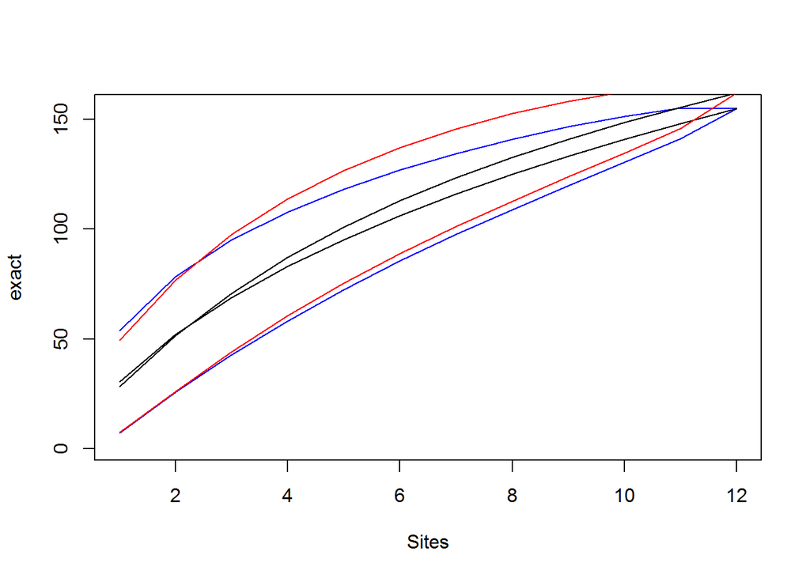

```r
#greenlines
gl<-specaccum(matrix[1:12, 4:246], method="exact", permutations = 999, conditioned = TRUE)
#upslope
up<-specaccum(matrix[13:24, 4:246], method="exact", permutations = 999, conditioned = TRUE)
plot(gl, ci.type="line", ci.col="blue")
plot(up, add=TRUE, ci.type="line", ci.col="red")
```

This code works, but I should implement it at a finer scale than over 12 sites. Quadrat level would work; need a solution for how to integrate woody species? Maybe just as a “woody” quadrat. Can test this code at for herbaceous plants only using the dataset used in the Permutation seminar. Note this is *herbaceous plants only*, and is missing morphospecies that could not be identified to species or species that do not have a definite native/introduced origin status.

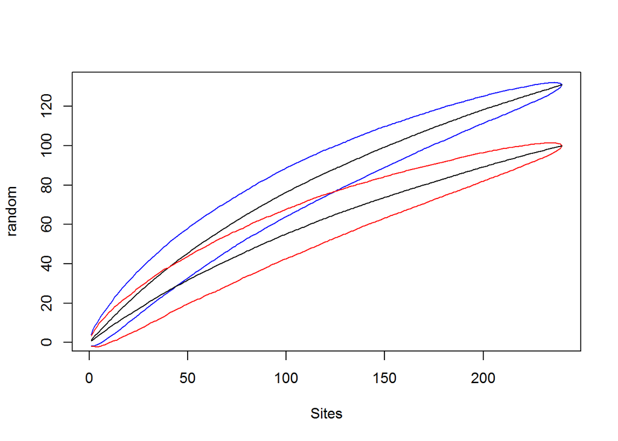

```r
herbs<-read.csv("herbs_quadratlevel.csv")

#greenlines
gl<-specaccum(herbs[1:240, 3:165], method="random", permutations = 999, conditioned = TRUE)
#upslope
up<-specaccum(herbs[241:480, 3:165], method="random", permutations = 999, conditioned = TRUE)
plot(gl, ci.type="line", ci.col="blue")
plot(up, add=TRUE, ci.type="line", ci.col="red")
```

Trying all this again for the full 2012 data set… quadrat equivalents for woody species have been established by dividing the woody transect into 1 m sequential plots.

Creating a site by species matrix at the quadrat scale, starting with a list of species presences (or abundances). This dataset just contains presences - I don’t think that it depends on including abundances, but doublecheck that. I think it’s fine when using sampled sites instead of sampled individuals.

```r
splist<-read.csv("species accumulations for 2012 obs 5_8_2014 b.csv")
require(reshape)
quadmat<- cast(splist,  Code + NewQuad ~ Species, value='Present', fun=mean) #mean is a placeholder here since this is just a presence list, mean of a bunch of 1s is 1

quadmat <- as.data.frame(quadmat) #fixes the recast as a data frame
quadmat[is.na(quadmat)] <- 0 #refills the empty cells with 0
```

Export quadmat to Excel to add the missing (empty) quadrats

```r
write.table(quadmat, file="quadmat2012.csv", sep=",", row.names=F)
```

Reimport the matrix and sort by elevation

```r
quadmatrix<-read.csv("quadmat2012allrows.csv")

#require(data.table)
#matsort<-data.table(matrix, key="Elev")
#matsort<-as.data.table(matsort)
#commented out this code - the current form of that csv file is already sorted
```

Run species accumulations - this is the code that works for the manuscript This works if I don’t run the matrix through the sorting process - something about data.table() breaks the data frame, apparently. No idea. But this code works now.

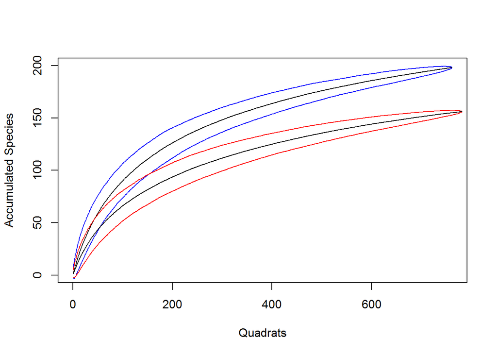

```r
#greenlines
gl<-specaccum(quadmatrix[1:761, 3:247], method="random", permutations = 999, conditioned = TRUE)
#upslope
up<-specaccum(quadmatrix[762:1542, 3:247], method="random", permutations = 999, conditioned = TRUE)
plot(gl, ci.type="line", ci.col="blue", xlab = "Quadrats", ylab = "Accumulated Species")
plot(up, add=TRUE, ci.type="line", ci.col="red")
```

Plotting the species accumulation curve in ggplot2 for better visualizations for print

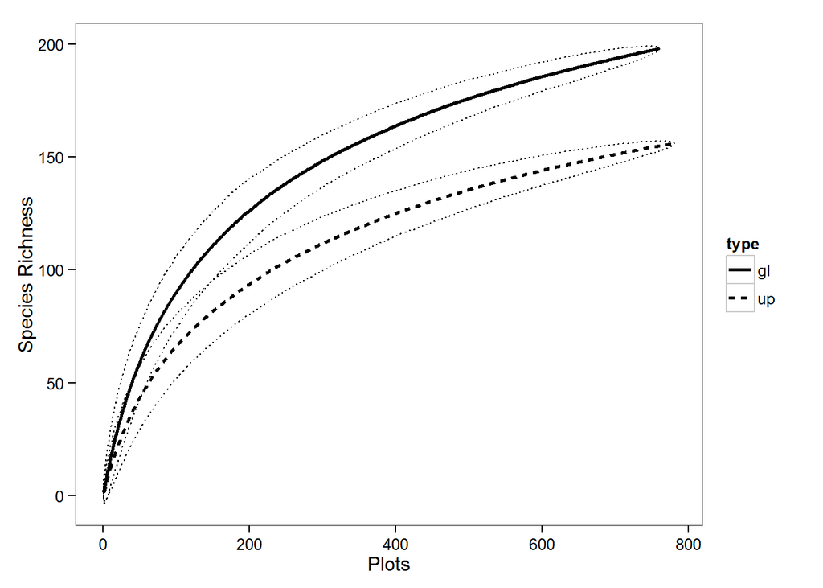

```r
#turn the specaccum output into a dataframe, add a column to label the site type (greenline or upslope)
upt<-as.data.frame(up[2:5])
upt["type"] <- NA
upt[is.na(upt)] <-"up"

#repeat the process for the greenline data
glt<-as.data.frame(gl[2:5])
glt["type"] <-NA
glt[is.na(glt)] <- "gl"

#merge the two data frames for plotting in ggplot

plottable<-rbind(upt,glt)

#make a plot
require(ggplot2)
ggplot(data=plottable, aes(x=sites, y=richness, shape=type)) +geom_ribbon(aes(ymax=richness+1.96*sd, ymin=richness-1.96*sd), fill= NA, linetype = 3, color = "black") + geom_line(aes(linetype=type), size=1) +theme_bw() + theme(panel.grid.major=element_line(color = NA), panel.grid.minor=element_line(color = NA)) + xlab("Plots") + ylab("Species Richness")
```

Testing online demos for comparison:

From http://www.ats.ucla.edu/stat/r/dae/poissonreg.htm

```r
p<-read.csv("http://www.ats.ucla.edu/stat/data/poisson_sim.csv")
p <- within(p, {
    prog <- factor(prog, levels = 1:3, labels = c("General", "Academic", "Vocational"))
    id <- factor(id)
})
summary(p)
```

```
##        id        num_awards           prog          math
##  1      :  1   Min.   :0.00   General   : 45   Min.   :33.0
##  2      :  1   1st Qu.:0.00   Academic  :105   1st Qu.:45.0
##  3      :  1   Median :0.00   Vocational: 50   Median :52.0
##  4      :  1   Mean   :0.63                    Mean   :52.6
##  5      :  1   3rd Qu.:1.00                    3rd Qu.:59.0
##  6      :  1   Max.   :6.00                    Max.   :75.0
##  (Other):194
```

```r
#This puts labels on the imported data sheet and then gives summary stats for each column

m1 <- glm(num_awards ~ prog + math, family = "poisson", data = p)
summary(m1)
```

```
##
## Call:
## glm(formula = num_awards ~ prog + math, family = "poisson", data = p)
##
## Deviance Residuals:
##    Min      1Q  Median      3Q     Max
## -2.204  -0.844  -0.511   0.256   2.680
##
## Coefficients:
##                Estimate Std. Error z value Pr(>|z|)
## (Intercept)     -5.2471     0.6585   -7.97  1.6e-15 ***
## progAcademic     1.0839     0.3583    3.03   0.0025 **
## progVocational   0.3698     0.4411    0.84   0.4018
## math             0.0702     0.0106    6.62  3.6e-11 ***
## ---
## Signif. codes:  0 '***' 0.001 '**' 0.01 '*' 0.05 '.' 0.1 ' ' 1
##
## (Dispersion parameter for poisson family taken to be 1)
##
##     Null deviance: 287.67  on 199  degrees of freedom
## Residual deviance: 189.45  on 196  degrees of freedom
## AIC: 373.5
##
## Number of Fisher Scoring iterations: 6
```

```r
#this gives a full model
#we can test a model removing prog and then compare the two using a chi-sq test

## update m1 model dropping prog
m2 <- update(m1, . ~ . - prog)
## test model differences with chi square test
anova(m2, m1, test = "Chisq")
```

```
## Analysis of Deviance Table
##
## Model 1: num_awards ~ math
## Model 2: num_awards ~ prog + math
##   Resid. Df Resid. Dev Df Deviance Pr(>Chi)
## 1       198        204
## 2       196        189  2     14.6  0.00069 ***
## ---
## Signif. codes:  0 '***' 0.001 '**' 0.01 '*' 0.05 '.' 0.1 ' ' 1
```